# Auckland Public Transport: A Commuter’s Visual Story

## Welcome aboard — what is this story about?

Every weekday, commuters across Auckland rely on **buses and trains** to get to work, school, and home again. But what is it actually *like* riding public transport during peak hours — how long do you wait, how crowded is it, and can you get a seat?

Over **two weeks in March 2026**, I personally logged **20 observations** of public transport trips, recording the transport type, time of day, crowding level, wait time, and seat availability using a Google Form.

20Trips observed

2Transport modes

~7.5 minAverage wait time

55%Trips: all seats taken

This visual story explores how **wait times**, **crowding**, and **seat availability** differ between Bus and Train/Metro across morning peak, afternoon peak, and evening trips.

## How long are commuters waiting?

The first question any commuter asks is: *how long do I have to stand on the kerb?*

The chart below compares average wait times across transport types and time periods. A clear pattern emerges — **morning peak is demanding for both modes**, with Bus averaging 8.2 minutes and Train/Metro 8.0 minutes. Afternoon peak Train/Metro waits climb even higher (9 minutes average), possibly due to service bunching after midday. Evening trips were the most comfortable, averaging just **4 minutes** to board.

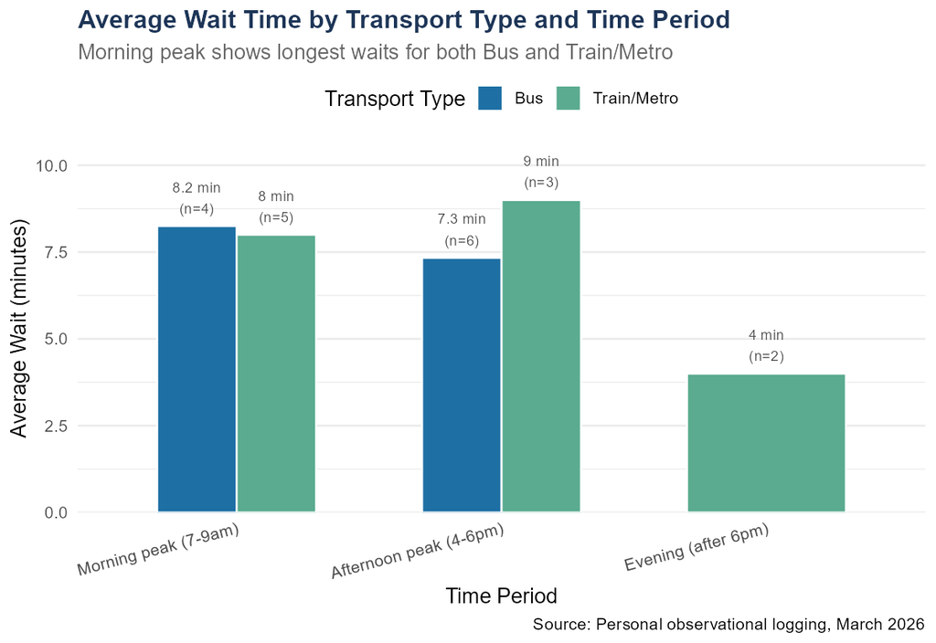

Bar chart showing average wait time in minutes for Bus and Train/Metro across Morning peak (7-9am), Afternoon peak (4-6pm), and Evening (after 6pm). Both modes average around 8 minutes in the morning. Afternoon peak Train/Metro is the longest at 9 minutes. Evening Train/Metro is the shortest at 4 minutes.

## How crowded does it get?

Waiting is one thing — but what greets you when the doors open?

The heatmap below maps the **distribution of crowding levels** experienced on each transport type. Both Bus and Train/Metro are most often **“Crowded”** (4 observations each). However, Bus skews more heavily toward the severe end — recording **4 “Very crowded”** trips versus just 1 for Train/Metro. Train/Metro shows a wider spread, with observations ranging from “Empty” to “Very crowded”, suggesting more variable occupancy across the day.

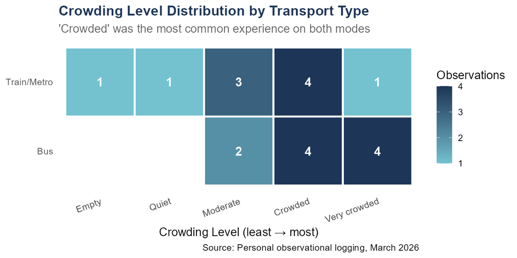

Heatmap showing crowding level on the x-axis from Empty to Very crowded, and transport type on the y-axis. Both modes have 4 Crowded observations. Bus has 4 Very crowded and 2 Moderate. Train/Metro has 1 Empty, 1 Quiet, 3 Moderate, 4 Crowded, and 1 Very crowded.

💡 **Key finding:** Bus rides tend toward the crowded extreme more often than trains — Train/Metro offers a broader range of experiences across the day.

## How did wait times shift over two weeks?

Looking at the full observation window, we can trace how wait times evolved **day by day** across March 2026. The scatter plot uses timestamps extracted with `{lubridate}`, with loess trend lines fitted separately for each transport mode.

Train/Metro (green) started with notably high waits in the first week (10–11 minutes) before dipping mid-period and surging again toward the end of March. Bus (blue) followed a more gradual arc. **Triangles** mark non-peak (evening) trips — these sit consistently at the bottom of the chart, confirming that off-peak travel is far more predictable and relaxed.

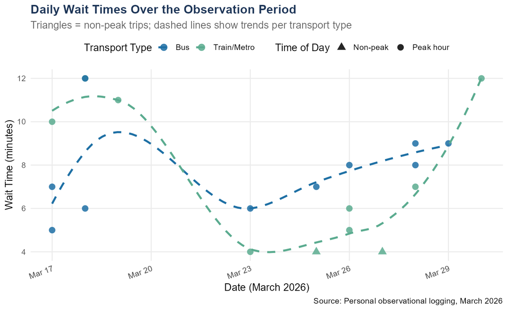

Scatter plot of individual trip wait times in minutes over dates from March 17 to March 30 2026. Points are blue for Bus and green for Train/Metro. Circle shapes are peak trips and triangles are non-peak. Dashed trend lines show each mode’s trajectory across the period. Train/Metro starts high around 10-11 minutes, dips mid-period, then rises sharply at the end.

💡 **Key finding:** Wait times are not stable — both modes show notable week-to-week variability, reminding us that any single trip is not representative of the whole commuting picture.

## The full picture: crowding, seats, and waiting together

Our final chart brings together **three dimensions at once**: crowding level, seat availability, and average wait time — displayed as a bubble chart faceted by transport type.

Bubble **size** encodes the number of observations at each combination, while **colour** shifts from teal (short wait) to red (long wait). For Bus, moderate crowding with some seats free carries a surprisingly warm red tint — suggesting even less-crowded buses can run behind schedule. For Train/Metro, the “Crowded / All taken” cell holds the largest bubbles, representing the most common commuting reality observed.

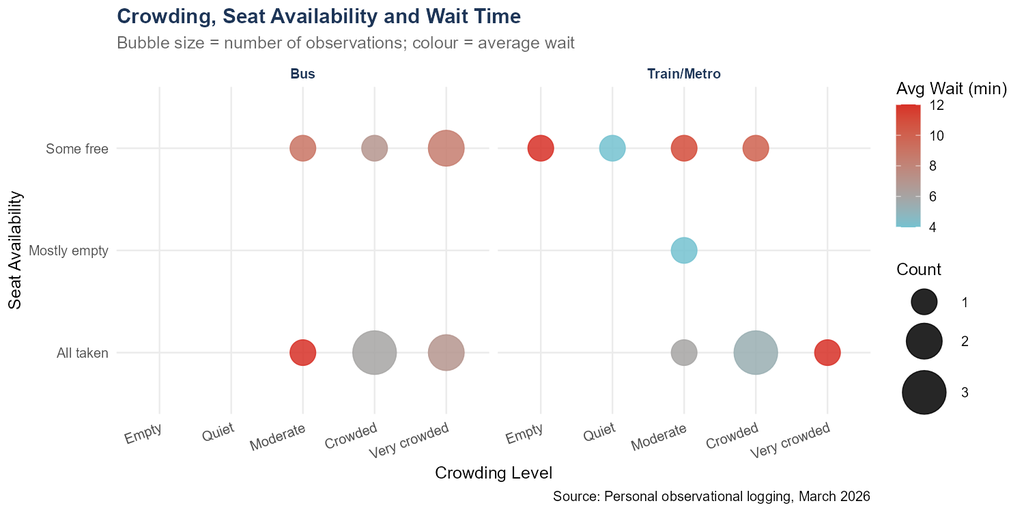

Bubble chart split into Bus and Train/Metro panels. The x-axis shows crowding level and the y-axis shows seat availability. Bubble size represents the number of observations and colour indicates average wait time on a scale from teal for short waits to red for long waits. Crowded and All taken is the most common combination in both panels.

💡 **Key finding:** High crowding and full seats go hand in hand — but long waits don’t always follow. Some of the longest waits appear on moderately crowded services, pointing to low service frequency rather than capacity as the real problem.

## What does this story tell us?

For any commuter choosing between Bus and Train/Metro: **if comfort and consistency matter, lean toward Train/Metro — especially outside peak hours.**

*Data collected via personal Google Form observational logging, March 2026.*